# Tumor Comparer

Rileen Sinha and Augustin Luna

2017-01-06

# Overview

Comparison of cell lines (the most popular experimental models of cancer) and tumors is challenging because of systematic differences between cell lines and tumors due to several factors, including biases in the selection of tumors for establishing cell lines, the process of immortalization of cell lines, and further changes gradually acquired by cell lines over time (e.g. due to passaging in culture).

This package includes a general computational method, TumorComparer, to systematically quantify similarities and differences between tumor material when detailed genetic and molecular profiles are available. Importantly, the comparisons can be flexibly tailored to a particular biological question by (interactively) placing a higher weight on functional alterations of interest (weighted similarity). This application allows this comparison to be run on cell lines in the comparison of six different cancer types to identify suitable as well as apparently unsuitable cell lines (including some widely used ones) for each cancer type.

This tutorial illustrates the method by comparing 25 lung squamous cancer (LUSC) cell lines from the Cancer Cell Line Encyclopedia (CCLE) to 178 tumors from the cancer genome atlas (TCGA) LUSC cohort, using mutations and copy number alterations, and weights emphasizing recurrent alterations found in the TCGA LUSC cohort.

# Getting started

```r
library(tumorcomparer)
```

A list of all accessible vignettes and methods is available with the following command.

```r
help.search("tumorcomparer")
```

# Load Data

```r
# Load pre-computed weights from R package
pancancer_gene_weights_file <- system.file("extdata", "weights", "default_weights_for_known_cancer_genes.txt", package="tumorcomparer")
cancer_specific_gene_weights_file <- system.file("extdata", "weights", "Genes_and_weights_TCGA_LUSC_based.txt", package="tumorcomparer")
tumor_mut_file <- system.file("extdata", "tumor_alterations", "TCGA_LUSC_MUT.txt", package="tumorcomparer")
tumor_cna_file <- system.file("extdata", "tumor_alterations", "TCGA_LUSC_CNA.txt", package="tumorcomparer")
cell_line_mut_file <- system.file("extdata", "cell_line_alterations", "CCLE_LUSC_MUT.txt", package="tumorcomparer")
cell_line_cna_file <- system.file("extdata", "cell_line_alterations", "CCLE_LUSC_CNA.txt", package="tumorcomparer")
# Do not save the output
output_composite_alteration_matrix_file <- NULL
# Use weighted correlation
distance_similarity_measure <- "weighted_correlation"
```

# Run Comparison

```r
comparison <- run_comparison(pancancer_gene_weights_file=pancancer_gene_weights_file,
               cancer_specific_gene_weights_file=cancer_specific_gene_weights_file,
               tumor_mut_file=tumor_mut_file,
               tumor_cna_file=tumor_cna_file,
               cell_line_mut_file=cell_line_mut_file,
               cell_line_cna_file=cell_line_cna_file,
               output_composite_alteration_matrix_file=output_composite_alteration_matrix_file,
               distance_similarity_measure=distance_similarity_measure)
# See returned outputs
names(comparison)
```

```
[1] "dist_mat"                         "isomdsfit"
[3] "cor_unweighted"                   "composite_mat"
[5] "composite_CNA"                    "composite_MUT"
[7] "cell_lines_with_both_MUT_and_CNA" "tumors_with_both_MUT_and_CNA"
```

# Plot Alteration Frequency Plot Results

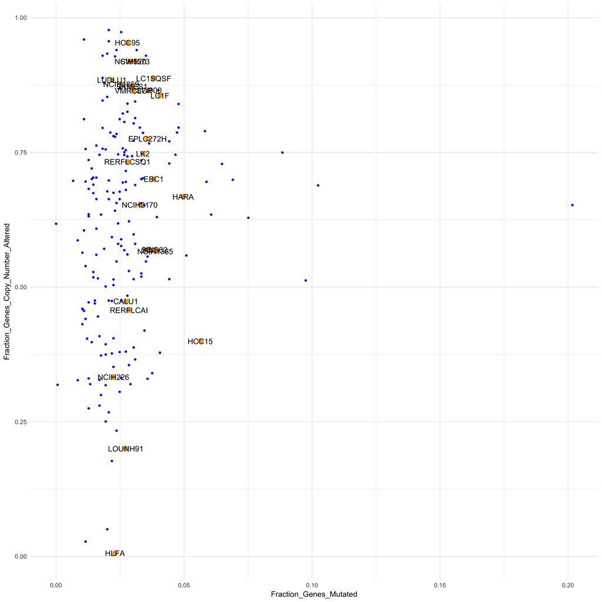

```r
plot_freq_alt(comparison_list=comparison, trim_cell_line_names=TRUE)
```

# Categorize Results

```r
categorization <- categorize_cell_lines(fraction_of_tumors_for_comparison=0.1,
                      dist_mat=comparison$dist_mat,
                      composite_mat=comparison$composite_mat,
                      cell_lines_with_both_MUT_and_CNA=comparison$cell_lines_with_both_MUT_and_CNA,
                      tumors_with_both_MUT_and_CNA=comparison$tumors_with_both_MUT_and_CNA,
                      trim_cell_line_names=TRUE)
# See returned outputs
names(categorization)
```

```
[1] "mean_similarity_cell_line_to_k_nearest_tumors" "mean_similarity_tumor_to_k_nearest_tumors"
[3] "categorization"
```

```r
kable((categorization$categorization))
```

| Sample_ID | Category |
| --- | --- |
| LC1F_LUNG | Great |
| LUDLU1_LUNG | Great |
| LC1SQSF_LUNG | Good |
| NCIH1385_LUNG | Good |
| NCIH2170_LUNG | Good |
| RERFLCSQ1_LUNG | Good |
| SW900_LUNG | Good |
| VMRCLCP_LUNG | Good |
| CALU1_LUNG | Moderately Good |
| EBC1_LUNG | Moderately Good |
| EPLC272H_LUNG | Moderately Good |
| HARA_LUNG | Moderately Good |
| HCC15_LUNG | Moderately Good |
| HCC95_LUNG | Moderately Good |
| KNS62_LUNG | Moderately Good |
| LK2_LUNG | Moderately Good |
| LOUNH91_LUNG | Moderately Good |
| NCIH1869_LUNG | Moderately Good |
| NCIH520_LUNG | Moderately Good |
| RERFLCAI_LUNG | Moderately Good |
| SQ1_LUNG | Moderately Good |
| SW1573_LUNG | Moderately Good |
| SKMES1_LUNG | Poor |
| HLFA_LUNG | Outliers |
| NCIH226_LUNG | Outliers |

# Plot MDS Results

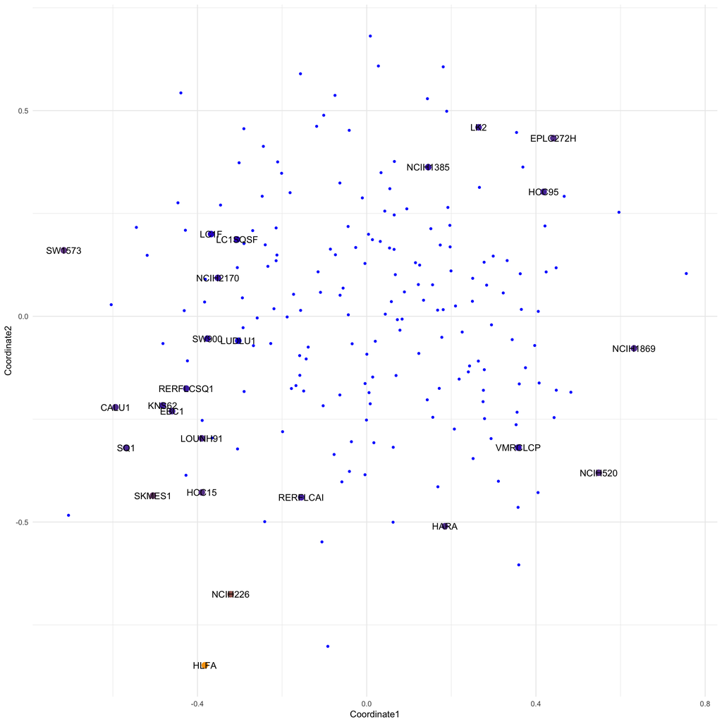

```r
plot_mds(comparison_list=comparison, categorization_list=categorization, trim_cell_line_names = TRUE)
```

# Single Cell Line Example

An illustrative example of how investigators can use this in their own research. We use a single cell line - CALU-1, a lung squamous cancer (LUSC) cell line, and genes present in the 341-gene MSK-IMPACT panel, a panel of genes used at Memorial Sloan-Kettering Cancer Center for precision medicine. The comparison is done using the TCGA LUSC tumor cohort and CALU-1, using the subset of MSK-IMPACT genes for which data is available (246). Based on the similarity of CALU-1 to the nearest 10 percent of tumors, as compared to the similarity of the tumors to their nearest 10 percent of tumors in this relatively heterogeneous set, the method assesses CALU-1 as a “moderately good match” to the tumors.

```r
cell_line_mut_file <- system.file("extdata", "single_cell_line_example", "cell_line_MUT.txt", package="tumorcomparer")
cell_line_cna_file <- system.file("extdata", "single_cell_line_example", "cell_line_CNA.txt", package="tumorcomparer")
cell_line_mut <- read.table(cell_line_mut_file, sep = "\t", header = TRUE, row.names = 1, check.names = FALSE)
cell_line_cna <- read.table(cell_line_cna_file, sep = "\t", header = TRUE, row.names = 1, check.names = FALSE)
# Mutation data
kable(head(cell_line_mut))
```

|  | CALU1_LUNG |
| --- | --- |
| ABL1 | 0 |
| AKT1 | 0 |
| AKT2 | 0 |
| AKT3 | 0 |
| ALK | 0 |
| APC | 1 |

```r
# Copy number data
kable(head(cell_line_cna))
```

|  | CALU1_LUNG |
| --- | --- |
| ABL1 | 0 |
| AKT1 | 0 |
| AKT2 | -1 |
| AKT3 | 0 |
| ALK | 0 |
| ALOX12B | -1 |

```r
comparison <- run_comparison(pancancer_gene_weights_file=pancancer_gene_weights_file,
               cancer_specific_gene_weights_file=cancer_specific_gene_weights_file,
               tumor_mut_file=tumor_mut_file,
               tumor_cna_file=tumor_cna_file,
               cell_line_mut_file=cell_line_mut_file,
               cell_line_cna_file=cell_line_cna_file,
               output_composite_alteration_matrix_file=output_composite_alteration_matrix_file,
               distance_similarity_measure=distance_similarity_measure)
categorization <- categorize_cell_lines(fraction_of_tumors_for_comparison=0.1,
                      dist_mat=comparison$dist_mat,
                      composite_mat=comparison$composite_mat,
                      cell_lines_with_both_MUT_and_CNA=comparison$cell_lines_with_both_MUT_and_CNA,
                      tumors_with_both_MUT_and_CNA=comparison$tumors_with_both_MUT_and_CNA,
                      trim_cell_line_names=TRUE)
# See returned outputs
names(categorization)
```

```
[1] "mean_similarity_cell_line_to_k_nearest_tumors" "mean_similarity_tumor_to_k_nearest_tumors"
[3] "categorization"
```

```r
kable((categorization$categorization))
```

| Sample_ID | Category |
| --- | --- |
| CALU1_LUNG | Moderately Good |

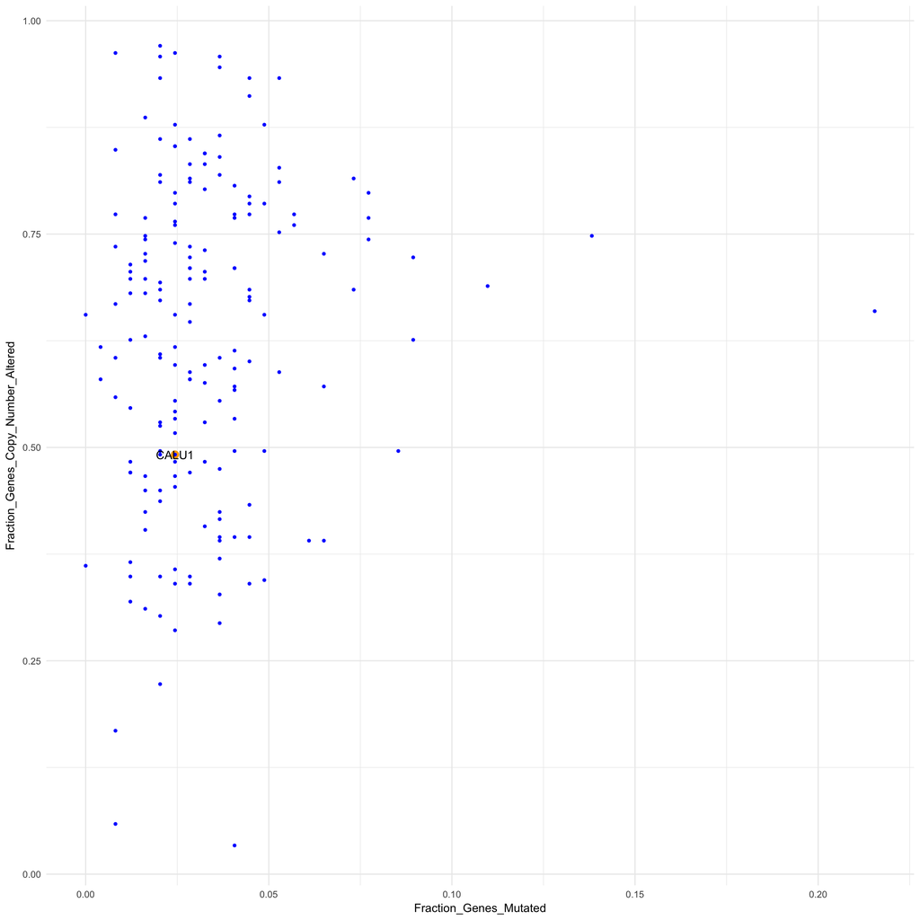

```r
plot_freq_alt(comparison_list=comparison, trim_cell_line_names=TRUE)
```

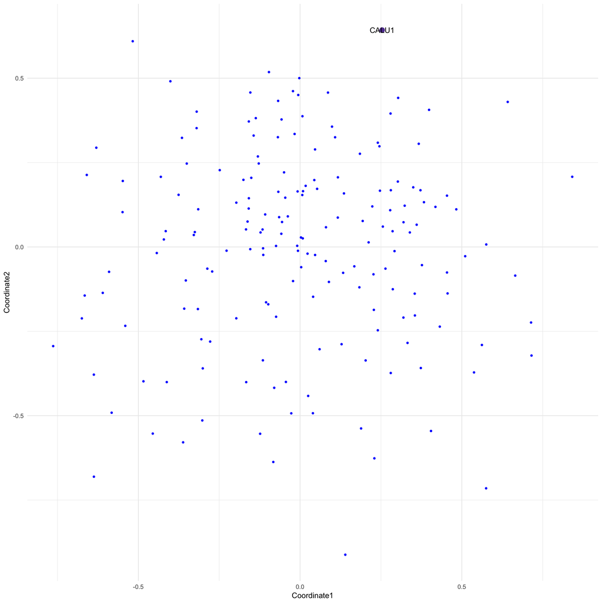

```r
plot_mds(comparison_list=comparison, categorization_list=categorization, trim_cell_line_names = TRUE)
```